# Solvency and Financial Structure in EU Insurance Markets A Comparative Study Based on Solvency II Indicators

Authors

Affiliation

Alejandra Citlalli Pacheco Tovar

HEC Lausanne

Aranxa Perez Oviedo

Laura Benczédi Munar

Published

November 12, 2025

# 1 Introduction

Insurance markets contribute significantly to economic stability by transforming uncertain risks into predictable financial commitments. As **[Arrow (1965)](https://doi.org/10.1007/978-3-642-20548-4)** describes, insurance represents the exchange of money today for money payable contingent upon the occurrence of certain events. This essential function relies on the sector’s ability to maintain adequate capital buffers and withstand adverse conditions. According to the European Insurance and Occupational Pensions Authority **[(EIOPA)](https://www.eiopa.europa.eu/browse/regulation-and-policy/solvency-ii_en#background-how-and-why-solvency-ii-came-to-life)**, the **Solvency II prudential regime**, in force since January 2016, establishes the requirements that insurance and reinsurance undertakings must meet to ensure adequate protection of policyholders and beneficiaries **(EIOPA, n.d.)**.

Despite the existence of this harmonized regulatory framework, significant differences across countries persist within the European Union. These divergences arise from economic, demographic, and structural characteristics, such as population size, gross domestic product (GDP) levels, mortality patterns, as well as more subjective elements including culture and risk appetite. As a result, EU countries can exhibit varying solvency ratios **[(EIOPA, 2023)](https://reports.insuranceeurope.eu/annual-report-2024-2025/s/28/about-insurance-europe)**, financial structures, and capital management strategies shaped by national economic conditions, supervisory practices, and the composition of insurers’ balance sheets.

This study conducts a comparative analysis of Solvency II indicators provided by EIOPA databases across EU countries, with the principal objective of identifying structural diversity, examining differences in investment composition, and providing an evidence based understanding of how, despite a common regulatory regime, national economic contexts shape distinct solvency and financial patterns across insurance markets.

## 1.1 Project Goals

Understanding how solvency levels, profitability, and expenses within insurance vary across countries and over time is of central importance in actuarial practice. Differences in insurers’ financial strength directly influence capital allocation, pricing strategies, and the early identification of potential financial stress. Similarly, recognising patterns in claims or premiums supports more accurate pricing, improved portfolio management, and stronger long-term risk control. Although this project will not explore the broader connection through all these areas, it seeks to present a very clear view of the available data in EIOPA Insurance Statistics website by offering insights that are relevant both for the stability of insurance companies and for the protection of policyholders.

Therefore to accomplish such task, we established 2 main objectives:

- **Exploratory Data Analysis (EDA):** Perform a descriptive analysis of insurers’ financial structures for the year 2024, detailed by quarterly performance and univariate analysis of key variables, such as assets, liabilities, Solvency Capital Requirement (SCR) ratio, Minimum Capital Requirement (MCR) ratio, etc.
- **Development of Visual Tools:** Produce visualizations such as maps, histograms, correlation matrix, bar charts, and comparative plots that facilitate interpretation and highlight key differences across countries and over time. The time series analysis will focus on the period from 2017 to 2024 with the aim of analyzing changes in solvency and other financial measures and identifying trends in the European insurance market.

## 1.2 Related work

Multiple lines of research have examined how insurers’ financial structures, investment decisions, and broader economic conditions influence solvency outcomes under the Solvency II framework. A broader macroeconomic perspective is offered by studies examining the insurance–growth nexus. In **[The Relationship Between Insurance and Economic Growth: Evidence from the European Union Countries](https://doi.org/10.1080/1331677x.2019.1588765)**, the authors analyse annual data from 2004 to 2015 to assess how insurance development interacts with economic growth **(Peleckienė et al., 2019)**. Their results show substantial cross-country heterogeneity: insurance sector development is generally higher in economically advanced countries, and the relationship between insurance penetration and economic growth varies significantly across member states. Some countries display positive and statistically significant relationships, others negative ones, and causality patterns differ across the EU, ranging from GDP-driven insurance growth to insurance-driven GDP growth or no detectable relationship.

Expanding on this line of inquiry, Siopi and Poufinas (2023) adopt a broader perspective in **[Impact of Internal and External Factors on Profitability and Financial Strength of Insurance Groups](https://doi.org/10.1007/s11294-023-09873-y)**. Studying 23 EU insurance groups from 2007 to 2021, they evaluate both profitability (ROA, ROE) and financial strength (equity-to-assets) in relation to firm-level characteristics and macroeconomic factors including GDP growth, inflation, long-term interest rates, and market structure. Their key conclusion is that, once these determinants are taken into account, the introduction of Solvency II does not exert a statistically significant effect on either profitability or financial strength **(Siopi & Poufinas, 2023)**. Instead, managerial efficiency, underwriting performance, portfolio composition, and broader economic conditions emerge as the dominant drivers. This result underscores that regulatory frameworks alone do not determine insurer performance; internal strategic decisions and macroeconomic environments often play a more decisive role.

Additional notable contributions include the study **Enterprise Risk Management and Solvency: The Case of the Listed EU Insurers**investigates the relationship between Enterprise Risk Management (ERM) adoption and solvency. As well as **Solvency II assumptions for increasing the international competitiveness of EU insurance industry** , where they analyze how Solvency II regime under implementation will help to increase the international competitiveness of EU insurance industry as they could reallocate own funds according the results of potential decrease or increase in solvency requirement relative to the standard formula. **(Peleckienė & Peleckis, 2014)**

Collectively, these studies emphasise that solvency, profitability, and financial resilience within EU insurance markets are shaped by a combination of investment structure, internal management decisions, risk-management practices, and broader macroeconomic conditions. They also highlight the cross-country variation that continues to exist despite the uniform regulatory environment established by Solvency II. However, none of these studies integrate all three dimensions within a single analysis.

In this paper, we aim to advance this discussion by examining the financial composition, solvency and profitability ratios of EU insurance companies to better understand how these elements relate to one another and how they differ across EU countries.

## 1.3 Research questions

Trying to connect the previous ideas about how financial structure affects solvency and profitability, and how these dimensions relate to each other, we construct the following research questions:

- **How do solvency patterns vary across the European Union countries and does solvency impact the countries’ profitability?**
- **To what extent does the relationship between assets and liabilities correlate with premiums collected and claims paid across EU countries?**
- **To what extent does the financial structure and asset allocation (e.g., investments in bonds) of insurers correlate with the volume of premiums collected across EU countries?**
- **Is there a relationship between the premiums earned in each country relative to their GDP?**

In summary, we aim to understand how regulatory framework factors and risk-management practices vary across EU countries, and how these differences impact profitability.

# 2 Data

## 2.1 Sources

This project analyzes the financial structure and insurance activity of EU countries using official supervisory data published downloaded from:

- **[European Insurance and Occupational Pensions Authority (EIOPA)](https://www.eiopa.europa.eu/index_en)**.
  - **[Balance Sheet (B)](https://www.eiopa.europa.eu/tools-and-data/insurance-statistics_en#own-funds)** Contains country-level information on assets and liabilities, distinguishing between life and non-life business and including reinsurance recoverables. This dataset supports a detailed assessment of insurers’ financial positions under Solvency II.
  - **[Premiums, Claims and Expenses (PCE)](https://www.eiopa.europa.eu/tools-and-data/insurance-statistics_en#own-funds)** Reports gross and net premiums, claims incurred, changes in technical provisions, and operating expenses for life and non-life insurance. It provides insight into insurers’ underwriting activity and operational performance (EIOPA, 2024).
  - **[Own Funds (O)](https://www.eiopa.europa.eu/tools-and-data/insurance-statistics_en#own-funds)** Includes Solvency Capital Requirement (SCR) and Minimum Capital Requirement (MCR), both in absolute values and percentile distributions (10th–90th), separately for life, non-life, and other undertakings.
- **[World Bank](https://data.worldbank.org/)**
  - Gross Domestic Price Idex
- **[Geographic Information System of the Commission. It provides the European Commission (GISCO)](https://ec.europa.eu/eurostat/web/gisco)**
  - Thematic and statistical maps of the European Union.

## 2.2 Data Management and Preparation

The data management process was conducted through several structured stages. All datasets were provided in CSV format and represented quaterly financial data.

The initial stage consisted of gaining a thorough understanding of the datasets. This involved examining their structure, identifying the presence of missing values, determining the variables most relevant to the study, and reviewing the variable types available for the exploratory analysis phase.

The variables identified as most relevant to the analysis were as follows:

| Group | Variables (Common) | Other Variables | Description of Other Variables |
| --- | --- | --- | --- |
| **Balance Sheet** | `Reporting country`, `Reference period` | `Item name`, `Value (Balance Sheet)` | Includes balance sheet components |
| **Premiums, Claims, Expenses** | `Reporting country`, `Reference period` | `Item name`, `Value (PCE)` | Includes premium, claims, and expense components |
| **Own Funds** | `Reporting country`, `Reference period` | `Item name`, `Value (Own Funds)` | Includes solvency metrics |

Before data processing, the individual datasets had the following dimensions:

**Balance Sheet:** (1049, 82)

**Premiums:** (1049, 44)

**Own Funds:** (66255, 8)

## 2.3 Data Collection and Loading

The initial inspection consisted of:

- Uploading each file to the working environment
- Using `.info()` and .`describe()` to inspect variable types, reporting frequency, and the extent of missing values

A key observation was that all datasets were in a “long format”, meaning:

- One column identified the variable (“Item Code” or “Item Name”)
- One column contained the corresponding numerical value

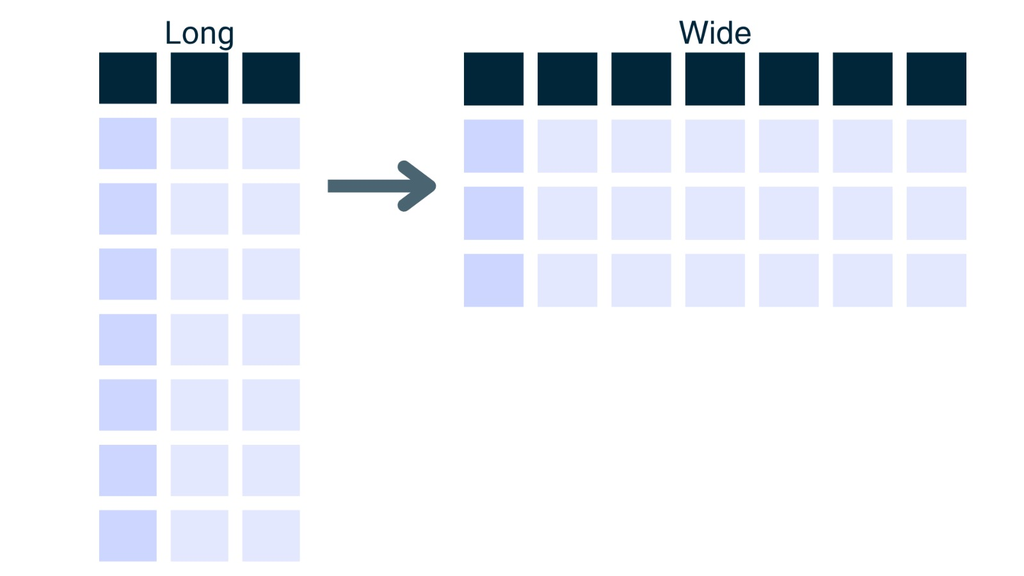

In our case, the original long structure (where each observation is stored in its own row and key identifiers such as Item Code and Value repeat) was not ideal for conducting cross-country and time-based financial analysis. A wide format is more appropriate because it consolidates each country-quarter into a single row and expands each Item Code into a dedicated column, simplifying merging, comparisons, and the computation of solvency or balance-sheet indicators.

A single variable column (“Value”) and a variable identifier column (“Item Code/Name”) were present in all files.